# Lab 12: Network Analysis using Cytoscape and RCy3

## Introduction to Network Analysis

Cytoscape is a popular tool for network analysis. It has been in developed for over 20 years and now has a robust ecosystem with many [plugins/apps](https://apps.cytoscape.org/) to for specific uses. Their is a detail user manual (which can be edited on [github](https://github.com/cytoscape/cytoscape-manual/tree/956f3b70754d79fbe25502f76af88edc3278d690/docs)) and [tutorials](https://github.com/cytoscape/cytoscape-tutorials/wiki).

Within R there are several alternative graph visualization packages including [igraph](https://igraph.org/r/) and the Bioconductor package [graph](https://www.bioconductor.org/packages/release/bioc/html/graph.html). Both are excellent packages however this past year a new R interface to Cytocape [Rcy3](https://bioconductor.org/packages/release/bioc/html/RCy3.html) was released which we will explore today. Here is the initial [publication](https://www.ncbi.nlm.nih.gov/pmc/articles/PMC6880260/pdf/f1000research-8-23766.pdf) describing `Rcy3`.

## On the Computer

### Cytoscape

- Download, install and open Cytoscape
- Read through the [Tour of Cytoscape](https://cytoscape.org/cytoscape-tutorials/protocols/tour-of-cytoscape/#/)
- Do the recommended exercises on `Basic Data Visualization` and `Differentially Expressed Genes`

### RCy3

- Go through the first vignette `Overview of RCy3`

#### Notes

Check to make sure it can connect to Cytoscape

```r
library(RCy3)
cytoscapePing()
```

```
## You are connected to Cytoscape!
```

Note that the code for the first graph will run in the R console, but not in Rmd (I am not sure why at the moment). All other code chunks knit fine, but the images appear in Cytoscape.

[output not shown]

The network will not appear in R, but in Cytoscape

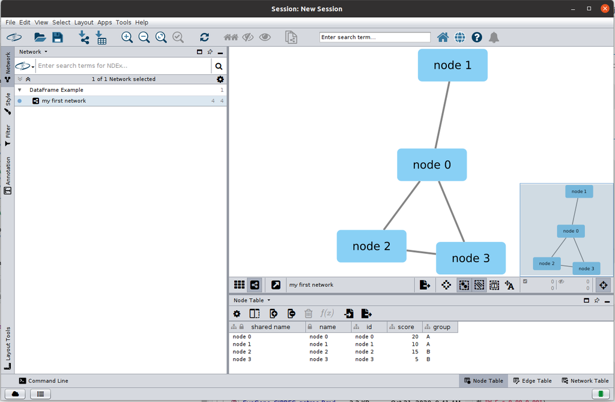

## Exercises

Create a .Rmd that shows your final graphs from the Cytoscape and RCy3 exercises. Link to your main course page.